# Chamela Adaptation Session 2

# Stochastic Linear Ornstein-Uhlenbeck models for Comparative Hypotheses

Let’s suppose the predictor is not a discrete regime mapping, but a continuous predictor. Here we have salamander data where temperatures were taken at two scales: The temperature of a salamander in its microhabitat and the “macroscale” temperature obtained for species via their geographic coordinates as mean average annual temperature from the BIOCLIM data raster.

```r
library(slouch)
library(treeplyr)
salDat <- readRDS("../data/SalamanderMicrohabitat.rds")
salDat
```

```
## $phy
##
## Phylogenetic tree with 26 tips and 25 internal nodes.
##
## Tip labels:
##   Desmognathus_wrighti, Desmognathus_imitator, Desmognathus_carolinensis, Desmognathus_ocoee, Desmognathus_orestes, Desmognathus_ochrophaeus, ...
##
## Rooted; includes branch lengths.
##
## $dat
## # A tibble: 26 × 5
##    Genus_species             Temp_macro_ave Temp_macro_errVar Soil_tem…¹ Soil_…²
##    <chr>                              <dbl>             <dbl>      <dbl>   <dbl>
##  1 Desmognathus_wrighti               11.9             0.217       14.6   0.217
##  2 Desmognathus_imitator              11.7             0.970       14.4   0.970
##  3 Desmognathus_carolinensis          13.3             5.21        11.5   5.21
##  4 Desmognathus_ocoee                 11.7             1.91        15.6   1.91
##  5 Desmognathus_orestes               12.9             0.0315      16.1   0.0315
##  6 Desmognathus_ochrophaeus           11.5             0.223       12.8   0.223
##  7 Plethodon_serratus                 14.8             0.534       11.2   0.534
##  8 Plethodon_cinereus                 13.2             0.0692      13.1   0.0692
##  9 Plethodon_hoffmani                 14.1             0.267       13.0   0.267
## 10 Plethodon_nettingi                  9.54            1.21         7.57  1.21
## # … with 16 more rows, and abbreviated variable names ¹Soil_temp_ave,
## #   ²Soil_temp_errVar
## # ℹ Use `print(n = ...)` to see more rows
```

Visualize the data with a phylomorphospace plot.

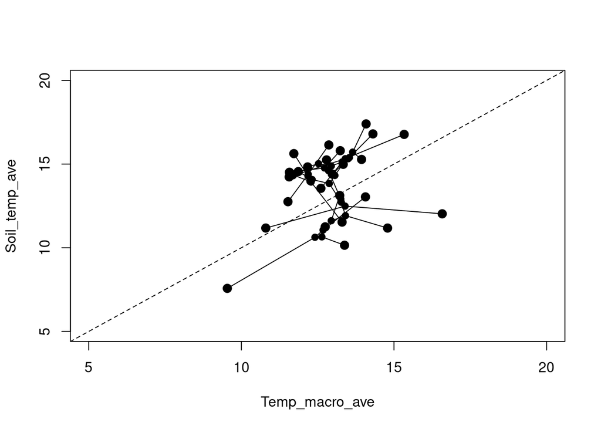

```r
phytools::phylomorphospace(salDat$phy, as.matrix(salDat$dat[,c("Temp_macro_ave", "Soil_temp_ave")]), xlim=c(5, 20), ylim=c(5, 20), ftype="off")
abline(0,1, lty=2) # One to one line
```

Perform a PGLS on the data using an OU model for the residuals in phylolm.

```r
library(phylolm)
rownames(salDat$dat) <- salDat$phy$tip.label
pgls_fit <- phylolm(Soil_temp_ave ~ Temp_macro_ave, data=salDat$dat, phy = salDat$phy, model = "OUfixedRoot")
summary(pgls_fit)
```

```
##
## Call:
## phylolm(formula = Soil_temp_ave ~ Temp_macro_ave, data = salDat$dat,
##     phy = salDat$phy, model = "OUfixedRoot")
##
##    AIC logLik
## 112.45 -52.22
##
## Raw residuals:
##     Min      1Q  Median      3Q     Max
## -4.3392 -1.6611  0.6535  1.2929  2.6409
##
## Mean tip height: 82.296
## Parameter estimate(s) using ML:
## alpha: 0.03924876
## sigma2: 0.3684509
##
## Coefficients:
##                Estimate  StdErr t.value p.value
## (Intercept)     5.93973 3.16760  1.8752 0.07299 .
## Temp_macro_ave  0.62608 0.23655  2.6467 0.01413 *
## ---
## Signif. codes:  0 '***' 0.001 '**' 0.01 '*' 0.05 '.' 0.1 ' ' 1
##
## R-squared: 0.2259    Adjusted R-squared: 0.1937
##
## Note: p-values and R-squared are conditional on alpha=0.03924876.
```

Now let’s fit a SLOUCH model. The first one we will fit will actually just repeat the previous exercise, and be another way of fitting a PGLS.

```r
library(slouch)
slouchpgls_fit <- slouch.fit(salDat$phy, species=salDat$phy$tip.label, response = salDat[['Soil_temp_ave']], direct.cov = salDat[['Temp_macro_ave']], hillclimb = TRUE)

summary(slouchpgls_fit)
```

```
## Important - Always inspect the likelihood surface of the model parameters with
##           grid search before evaluating model fit & results.
##
##   Maximum-likelihood estimates
##                        Estimate
## Phylogenetic half-life 17.66058
## Stationary variance    4.693819
##
##   Inferred maximum-likelihood parameters
##                                     Value
## Mean phylogenetic correction factor 0.7026475
## Rate of adaptation                  0.03924827
## Diffusion variance                  0.3684486
##
##   Interval of parameters in 3d plot (Sensitive to grid mesh, grid size and local ML estimate)
##                         Minimum  Maximum
## Phylogenetic half-life 14.25182 14.25182
## Stationary variance     4.93565  4.93565
##
##   Intercepts
##             Estimates Std. error
## (Intercept)  5.939713   3.043332
##
##   Direct-effect slope
##                            Estimates Std. error
## salDat[["Temp_macro_ave"]] 0.6260782  0.2272724
##
##   Model fit summary
##             Values
## Support    -52.200
## AIC        112.000
## AICc       114.000
## SIC        117.000
## R squared    0.226
## SST         33.600
## SSE         26.000
## N (params)   4.000
```

Next, we will allow the predictor to be a `random covariate`, or a predictor that evolves via Brownian Motion that has an effect on the primary optimum. We will now obtain two regressions, and “evolutionary regression” corresponding to the realized relationship, and an “optimal regression” representing what?

```r
slouch_fit <- slouch.fit(salDat$phy, species=salDat$phy$tip.label, response = salDat[['Soil_temp_ave']], random.cov = salDat[['Temp_macro_ave']], hillclimb = TRUE)

summary(slouch_fit)
```

```
## Important - Always inspect the likelihood surface of the model parameters with
##           grid search before evaluating model fit & results.
##
##   Maximum-likelihood estimates
##                        Estimate
## Phylogenetic half-life 17.4215
## Stationary variance    3.988795
##
##   Stochastic predictor(s)
##                            Phylogenetic mean Diffusion variance
## salDat[["Temp_macro_ave"]]          13.06356          0.1868095
##
##   Inferred maximum-likelihood parameters
##                                     Value
## Mean phylogenetic correction factor 0.7061491
## Rate of adaptation                  0.03978689
## Diffusion variance                  0.3174035
##
##   Interval of parameters in 3d plot (Sensitive to grid mesh, grid size and local ML estimate)
##                         Minimum  Maximum
## Phylogenetic half-life 23.43809 23.43809
## Stationary variance     4.93565  4.93565
##
##   Intercepts
##             Estimates Std. error
## (Intercept)  6.148544   3.076635
##
##   Optimal regression slope
##                            Estimates Std. error
## salDat[["Temp_macro_ave"]] 0.8661146   0.324032
##
##   Evolutionary regression slope
##                            Predictions Std. error
## salDat[["Temp_macro_ave"]]    0.611606  0.2288149
##
##   Model fit summary
##             Values
## Support    -52.300
## AIC        113.000
## AICc       115.000
## SIC        118.000
## R squared    0.217
## SST         33.000
## SSE         25.800
## N (params)   4.000
```

So far we have ignored measurement error. What do you predict the effect will be of measurement error on: 1. Phylogenetic signal? 2. How will error in Y affect the slope? 3. How will error in X affect the slope?

```r
slouchme_fit <- slouch.fit(salDat$phy, species=salDat$phy$tip.label, response = salDat[['Soil_temp_ave']], mv.response = salDat[['Soil_temp_errVar']],
                           random.cov = salDat[['Temp_macro_ave']], mv.random.cov = salDat[['Temp_macro_errVar']], hillclimb = TRUE)

summary(slouchme_fit)
```

```
## Important - Always inspect the likelihood surface of the model parameters with
##           grid search before evaluating model fit & results.
##
##   Maximum-likelihood estimates
##                        Estimate
## Phylogenetic half-life 25.11471
## Stationary variance    3.233399
##
##   Stochastic predictor(s)
##                            Phylogenetic mean Diffusion variance
## salDat[["Temp_macro_ave"]]          13.10279          0.1149756
##
##   Inferred maximum-likelihood parameters
##                                     Value
## Mean phylogenetic correction factor 0.6051513
## Rate of adaptation                  0.02759925
## Diffusion variance                  0.1784788
##
##   Interval of parameters in 3d plot (Sensitive to grid mesh, grid size and local ML estimate)
##                         Minimum  Maximum
## Phylogenetic half-life 79.62326 79.62326
## Stationary variance     4.93565  4.93565
##
##   Intercepts
##             Estimates Std. error
## (Intercept)  6.535056   2.998956
##
##   Optimal regression slope
##                            Estimates Std. error
## salDat[["Temp_macro_ave"]] 0.9802655  0.3656314
##
##   Evolutionary regression slope
##                            Predictions Std. error
## salDat[["Temp_macro_ave"]]    0.593209  0.2212623
##
##   Attenuation factor. Linear model coefficients (above) are not corrected for bias.
##
## (Intercept)                1 -0.949
## salDat[["Temp_macro_ave"]] 0  1.080
##
##   Model fit summary
##            Values
## Support    -51.60
## AIC        111.00
## AICc       113.00
## SIC        116.00
## R squared    0.22
## SST         32.70
## SSE         25.50
## N (params)   4.00
```

Now let’s plot the optimal and evolutionary regressions.

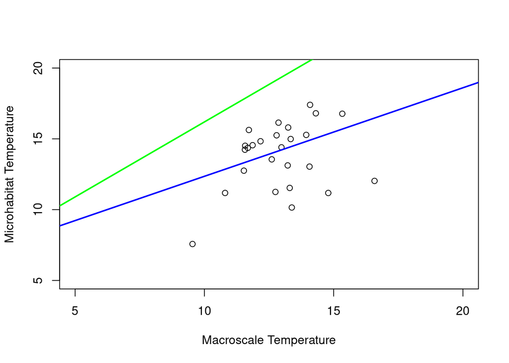

```r
plot(salDat[['Temp_macro_ave']], salDat[['Soil_temp_ave']], xlim=c(5, 20), ylim=c(5,20), xlab="Macroscale Temperature", ylab="Microhabitat Temperature")
abline(slouchme_fit$beta_primary$coefficients_bias_corr[1,1], slouchme_fit$beta_primary$coefficients_bias_corr[2,1], col="green", lwd=2)
abline(slouchme_fit$beta_evolutionary$coefficients_bias_corr[1,1], slouchme_fit$beta_evolutionary$coefficients_bias_corr[2,1], col="blue", lwd=2)
```

Let’s inspect the likelihood surface. This is a key step to understanding the uncertainty in your parameters. We will show the surface two log likelihood units below the peak, as this allows us to determine the well-supported regions of parameter space.

```r
hls <- seq(0.0001, 300, length.out=40)
vys <- seq(0.01, 25, length.out=40)

slouch_gridsearch <- slouch.fit(salDat$phy, species=salDat$phy$tip.label, response = salDat[['Soil_temp_ave']], mv.response = salDat[['Soil_temp_errVar']],
                           random.cov = salDat[['Temp_macro_ave']], mv.random.cov = salDat[['Temp_macro_errVar']], hl_values = hls, vy_values = vys)
```

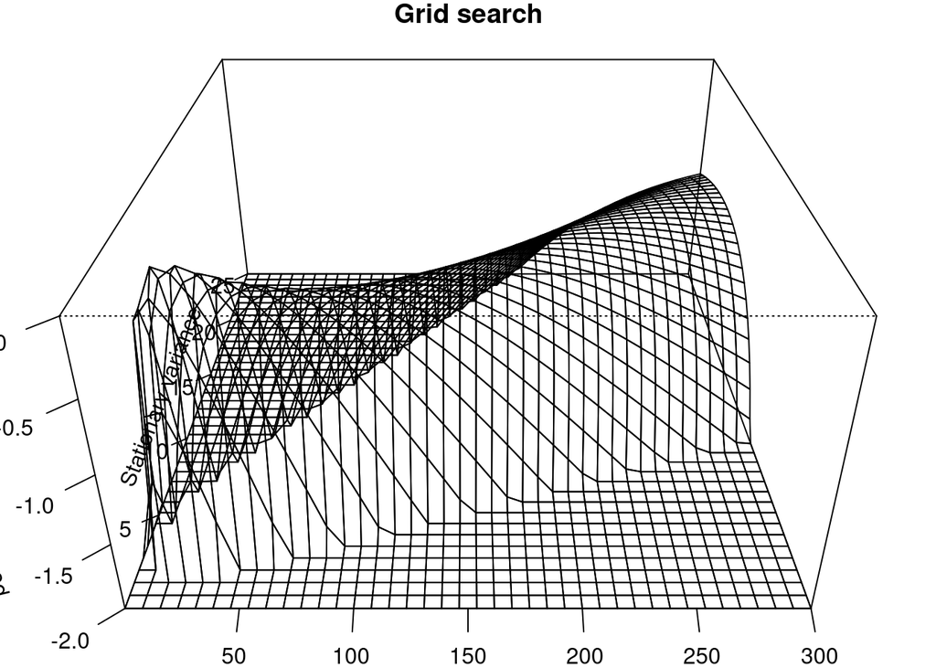

```r
par(mar=c(1,1,1,1))
plot(slouch_gridsearch, theta=0)
```

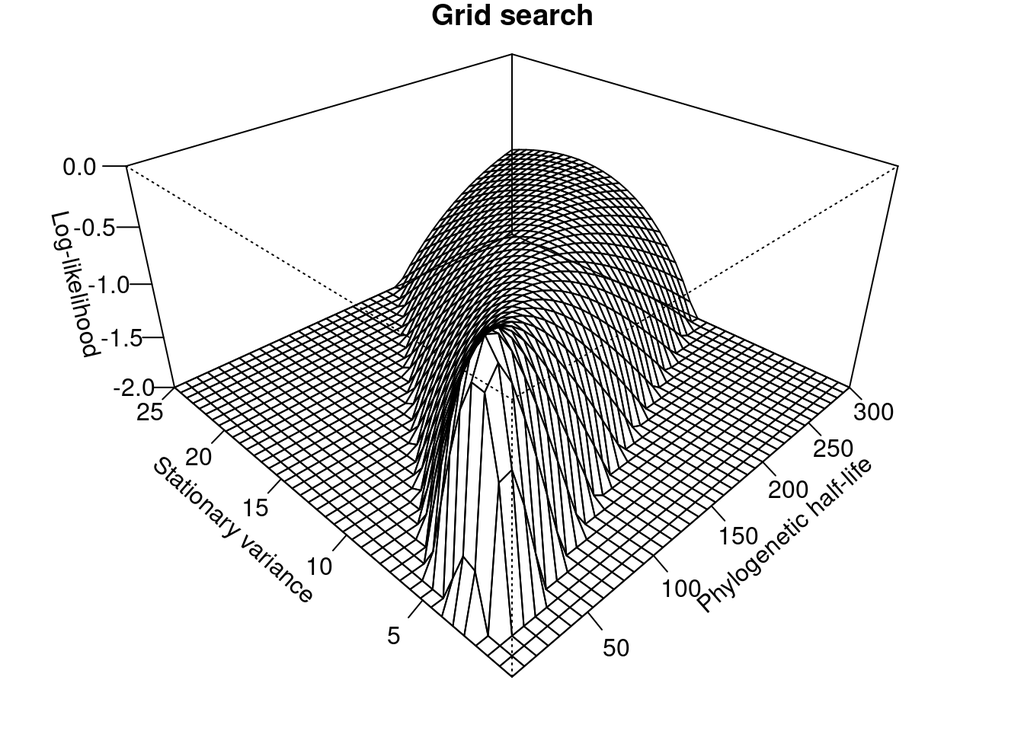

```r
plot(slouch_gridsearch, theta=-45)
```

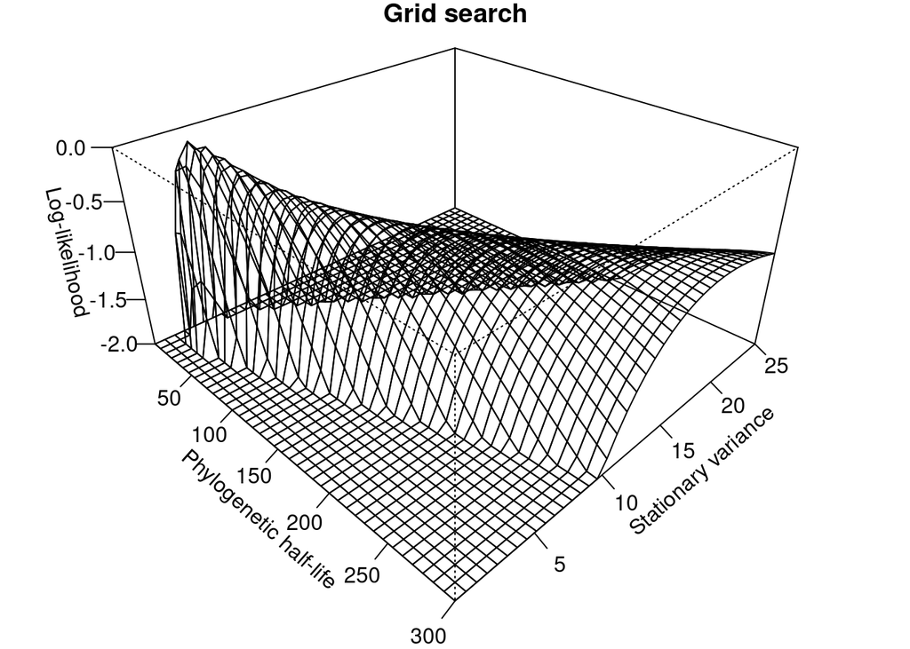

```r
plot(slouch_gridsearch, theta=45)
```

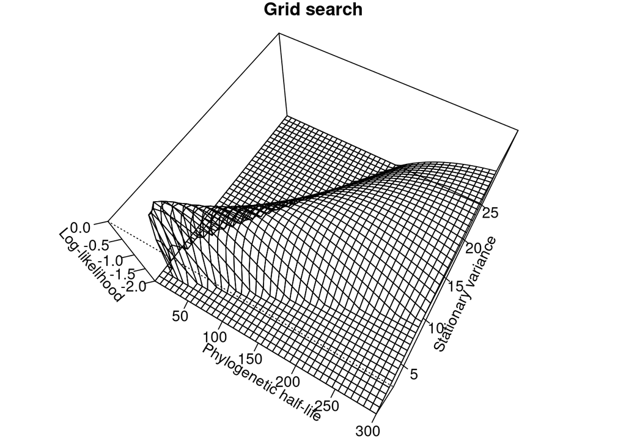

```r
plot(slouch_gridsearch, phi=60)
```